# Include name and location of the Fishery. One line only.

#### M-at-Age

Natural mortality-at-age for 3 simulations in the first historical year, the last historical year (i.e., current year), and the last projected year:

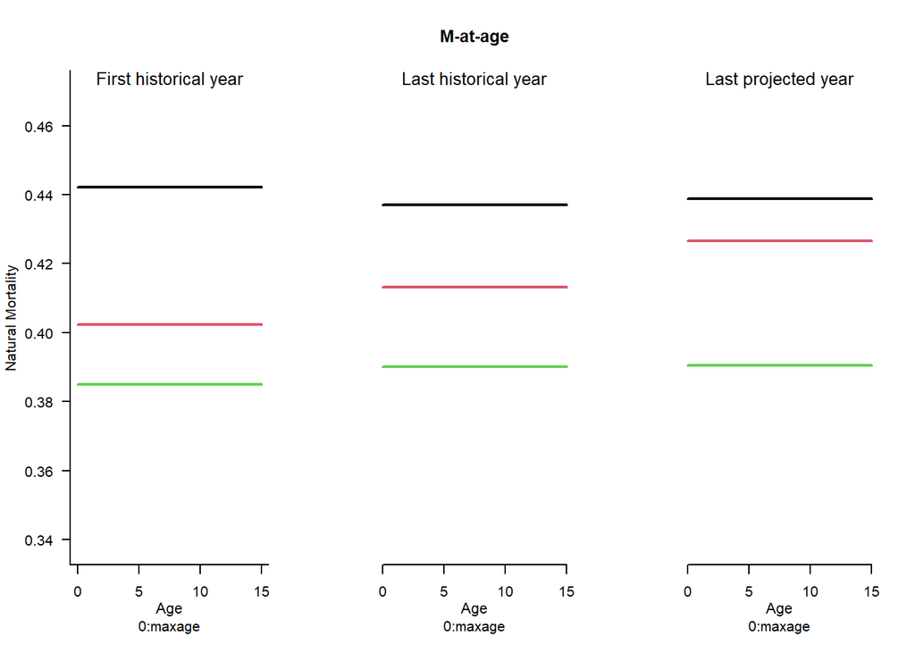

#### M-at-Length

Natural mortality-at-length for 3 simulations in the first historical year, the last historical year (i.e., current year), and the last projected year:

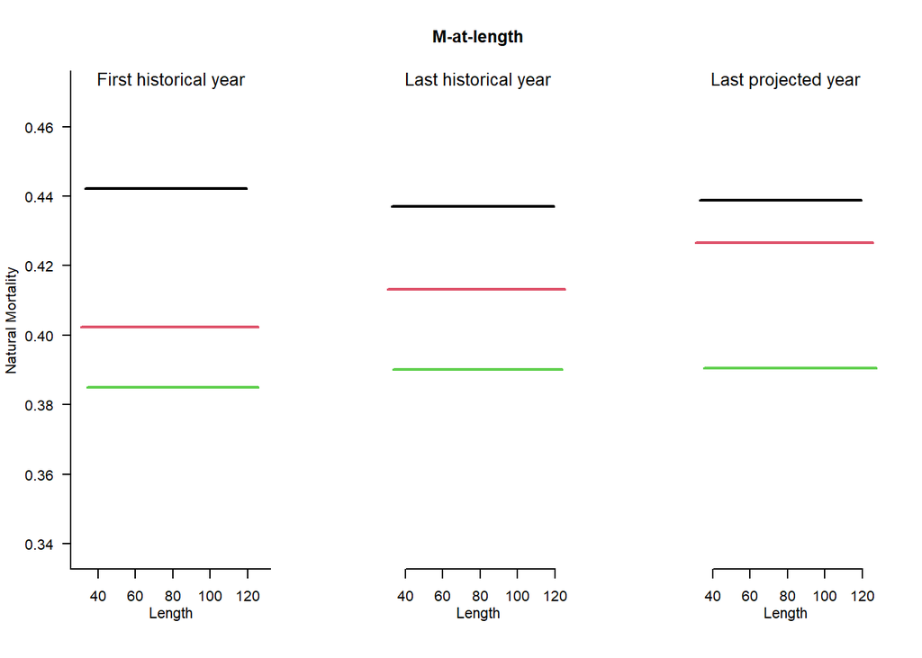

### Recruitment: h, SRrel, Perr, AC

**h**: Steepness of the stock recruit relationship. Uniform distribution lower and upper bounds. Values from 1/5 to 1

Specified Value(s): 0.65, 0.85

Borrowed from: Albacore

**SRrel**: Type of stock-recruit relationship. Single value, switch (1) Beverton-Holt (2) Ricker. Integer

Specified Value(s): 1

Borrowed from: Albacore

**Perr**: Process error, the CV of log-normal recruitment deviations. Uniform distribution lower and upper bounds. Non-negative real numbers

Specified Value(s): 0.15, 0.3

Borrowed from: Albacore

**AC**: Auto-correlation in recruitment deviations rec(t)=AC*rec(t-1)+(1-AC)*sigma(t). Uniform distribution lower and upper bounds. Non-negative real numbers

Specified Value(s): 0.1, 0.9

Borrowed from: Albacore

### Recruitment Parameters

#### Sampled Parameters

Histograms of 48 simulations of steepness (`h`), recruitment process error (`Perr`) and auto-correlation (`AC`) for the Beverton-Holt stock-recruitment relationship, with vertical colored lines indicating 3 randomly drawn values used in other plots:

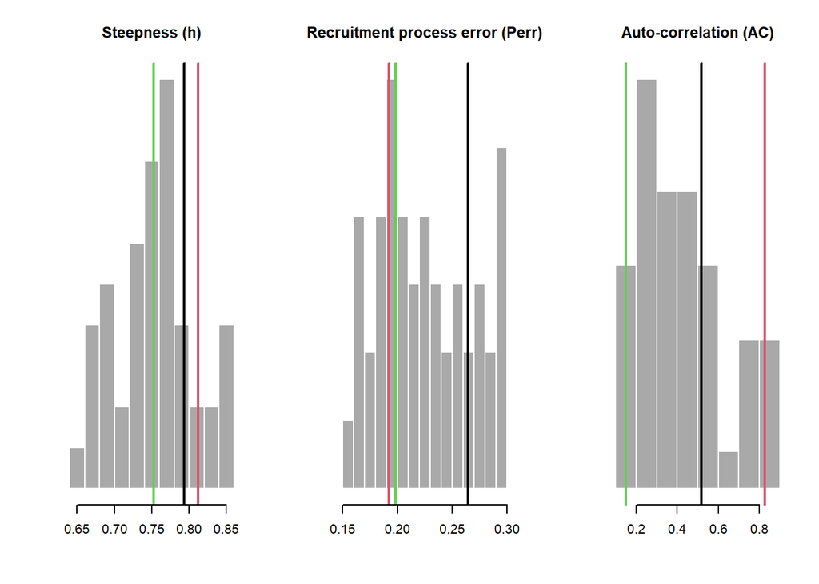

#### Time-Series

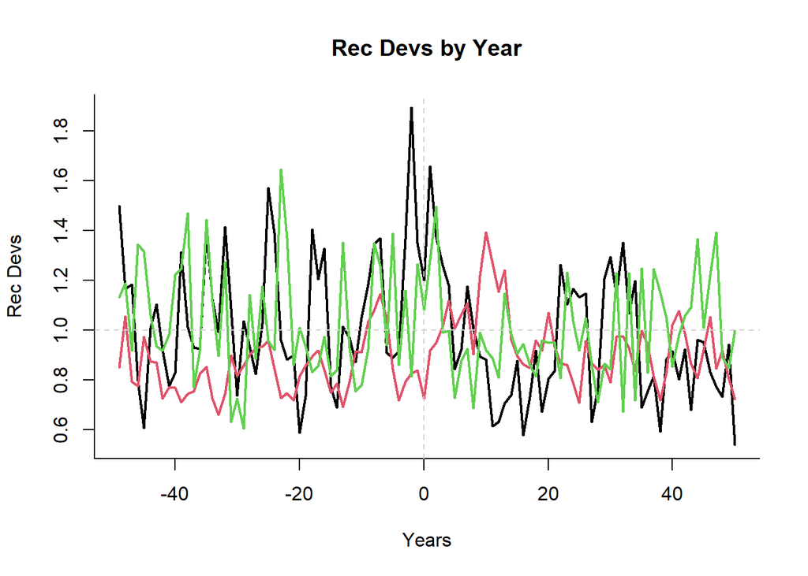

### Growth: Linf, K, t0, LenCV, Ksd, Linfsd

**Linf**: Maximum length. Uniform distribution lower and upper bounds. Positive real numbers

Specified Value(s): 121, 135

Borrowed from: Albacore

**K**: von Bertalanffy growth parameter k. Uniform distribution lower and upper bounds. Positive real numbers

Specified Value(s): 0.16, 0.22

Borrowed from: Albacore

**t0**: von Bertalanffy theoretical age at length zero. Uniform distribution lower and upper bounds. Non-positive real numbers

Specified Value(s): -1.86, -1.41

Borrowed from: Albacore

**LenCV**: Coefficient of variation of length-at-age (assumed constant for all age classes). Uniform distribution lower and upper bounds. Positive real numbers

Specified Value(s): 0.1, 0.1

Borrowed from: Albacore

**Ksd**: Inter-annual variability in growth parameter k expressed as coefficient of variation. Uniform distribution lower and upper bounds. Non-negative real numbers

Specified Value(s): 0, 0.03

Borrowed from: Albacore

**Linfsd**: Inter-annual variability in maximum length expressed as a coefficient of variation. Uniform distribution lower and upper bounds. Non-negative real numbers

Specified Value(s): 0, 0.03

Borrowed from: Albacore

### Growth Parameters

#### Sampled Parameters

Histograms of simulations of von Bertalanffy growth parameters `Linf`, `K`, and `t0`, and inter-annual variability in Linf and K (`Linfsd` and `Ksd`), with vertical colored lines indicating 3 randomly drawn values used in other plots:

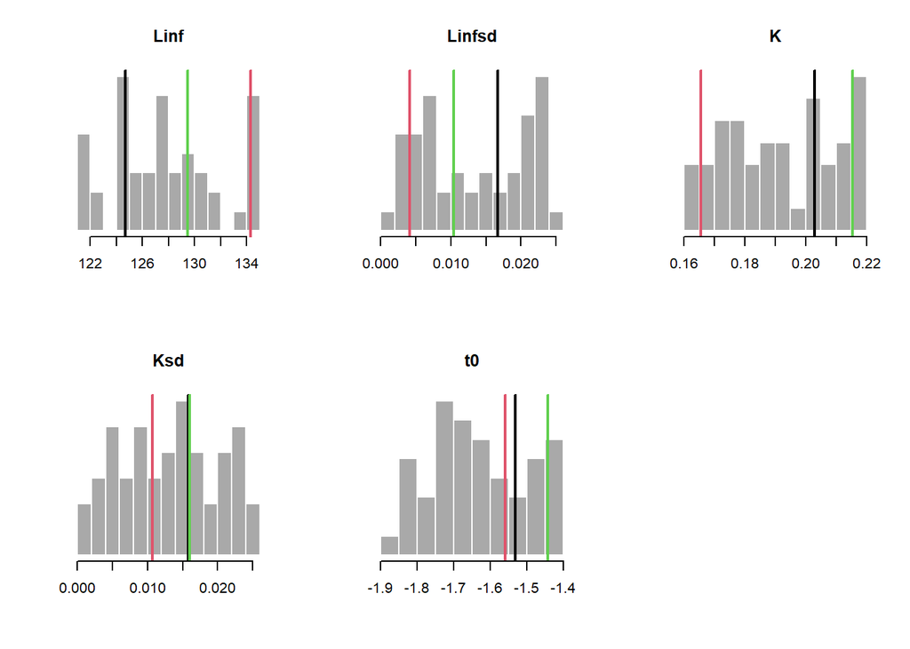

#### Time-Series

The Linf and K parameters in each year for 3 simulations. The vertical dashed line indicates the end of the historical period:

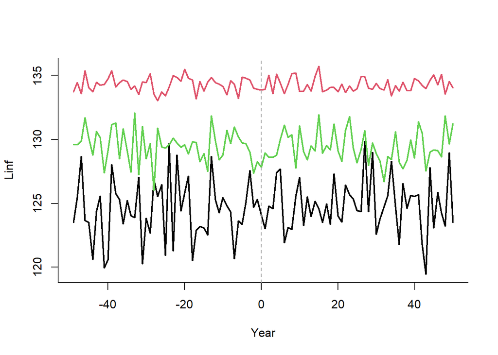

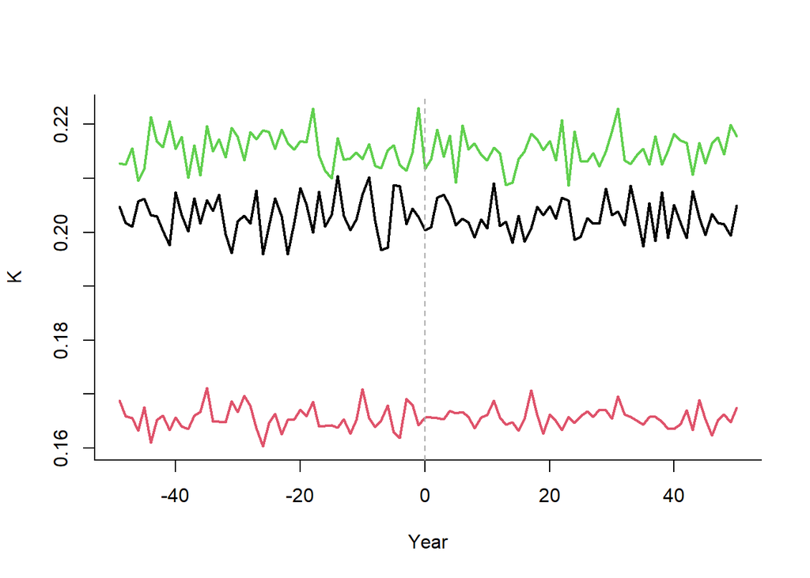

#### Growth Curves

Sampled length-at-age curves for 3 simulations in the first historical year, the last historical year, and the last projection year.

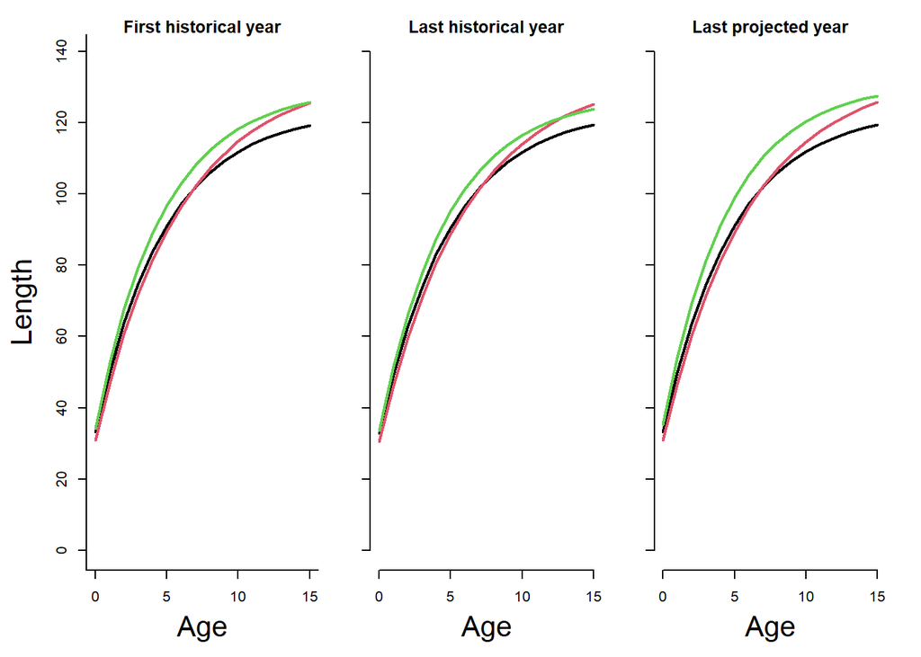

### Maturity: L50, L50_95

**L50**: Length at 50 percent maturity. Uniform distribution lower and upper bounds. Positive real numbers

Specified Value(s): 81, 91

Borrowed from: Albacore

**L50_95**: Length increment from 50 percent to 95 percent maturity. Uniform distribution lower and upper bounds. Positive real numbers

Specified Value(s): 10, 13

Borrowed from: Albacore

### Maturity Parameters

#### Sampled Parameters

Histograms of simulations of `L50` (length at 50% maturity), `L95` (length at 95% maturity), and corresponding derived age at maturity parameters (`A50` and `A95`), with vertical colored lines indicating 3 randomly drawn values used in other plots:

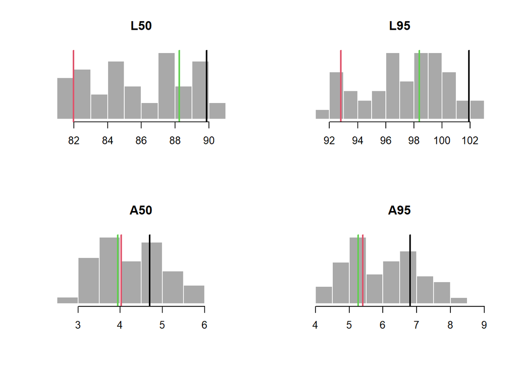

#### Maturity at Age and Length

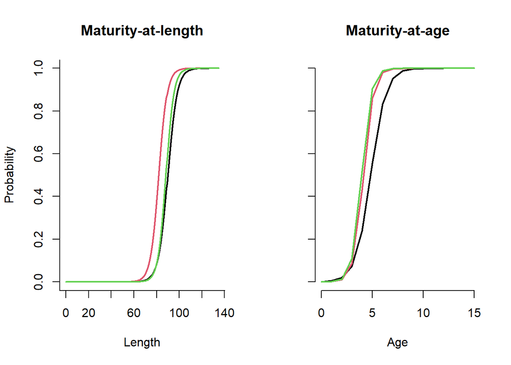

### Stock depletion and Discard Mortality: D, Fdisc

**D**: Current level of stock depletion SSB(current)/SSB(unfished). Uniform distribution lower and upper bounds. Fraction

Specified Value(s): 0.05, 0.6

Borrowed from: Albacore

**Fdisc**: Fraction of discarded fish that die. Uniform distribution lower and upper bounds. Non-negative real numbers

Specified Value(s): 0, 0

Borrowed from: Albacore

### Depletion and Discard Mortality

#### Sampled Parameters

Histograms of simulations of depletion (spawning biomass in the last historical year over average unfished spawning biomass; `D`) and the fraction of discarded fish that are killed by fishing mortality (`Fdisc`), with vertical colored lines indicating 3 randomly drawn values.

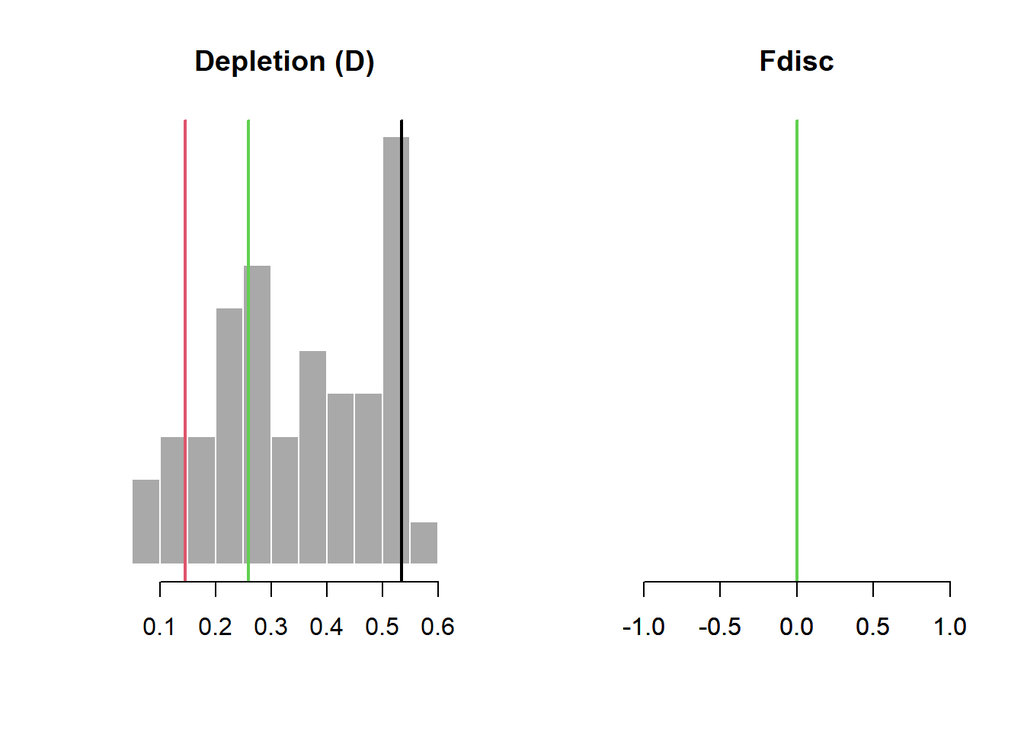

### Length-weight conversion parameters: a, b

**a**: Length-weight parameter alpha. Single value. Positive real number

Specified Value(s): 0

Borrowed from: Albacore

**b**: Length-weight parameter beta. Single value. Positive real number

Specified Value(s): 3.11

Borrowed from: Albacore

### Spatial distribution and movement: Size_area_1, Frac_area_1, Prob_staying

**Size_area_1**: The size of area 1 relative to area 2. Uniform distribution lower and upper bounds. Positive real numbers

Specified Value(s): 0.1, 0.1

Borrowed from: Albacore

**Frac_area_1**: The fraction of the unfished biomass in stock 1. Uniform distribution lower and upper bounds. Positive real numbers

Specified Value(s): 0.1, 0.1

Borrowed from: Albacore

**Prob_staying**: The probability of individuals in area 1 remaining in area 1 over the course of one year. Uniform distribution lower and upper bounds. Positive fraction.

Specified Value(s): 0.8, 0.9

Borrowed from: Albacore

### Spatial & Movement

#### Sampled Parameters

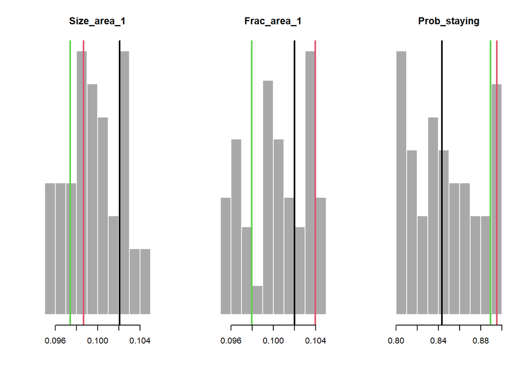

# Fleet Parameters

### Historical years of fishing, spatial targeting: nyears, Spat_targ

**nyears**: The number of years for the historical spool-up simulation. Single value. Positive integer

Specified Value(s): 50

Borrowed from: Generic_Flat effort

**Spat_targ**: Distribution of fishing in relation to spatial biomass: fishing distribution is proportional to B^Spat_targ. Uniform distribution lower and upper bounds. Real numbers

Specified Value(s): 1, 1

Borrowed from: Generic_Flat effort

### Trend in historical fishing effort (exploitation rate), interannual variability in fishing effort: EffYears, EffLower, EffUpper, Esd

**EffYears**: Years representing join-points (vertices) of time-varying effort. Vector. Non-negative real numbers

Borrowed from: Generic_Flat effort

**EffLower**: Lower bound on relative effort corresponding to EffYears. Vector. Non-negative real numbers

Borrowed from: Generic_Flat effort

**EffUpper**: Upper bound on relative effort corresponding to EffYears. Vector. Non-negative real numbers

Borrowed from: Generic_Flat effort

| EffYears | EffLower | EffUpper |
| --- | --- | --- |
| 1 | 0.0 | 0.0 |
| 17 | 0.4 | 0.6 |
| 34 | 0.4 | 0.6 |
| 50 | 0.4 | 0.6 |

**Esd**: Additional inter-annual variability in fishing mortality rate. Uniform distribution lower and upper bounds. Non-negative real numbers

Specified Value(s): 0.1, 0.4

Borrowed from: Generic_Flat effort

### Historical Effort

#### Sampled Parameters

Histograms of 48 simulations of inter-annual variability in historical fishing mortality (`Esd`), with vertical colored lines indicating 3 randomly drawn values used in the time-series plot:

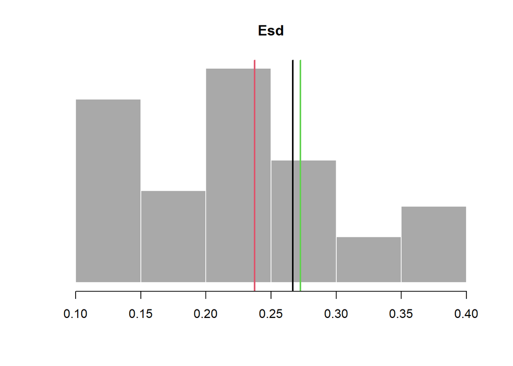

#### Time-Series

Time-series plot showing 3 trends in historical fishing mortality (`OM@EffUpper` and `OM@EffLower` or `OM@cpars$Find`):

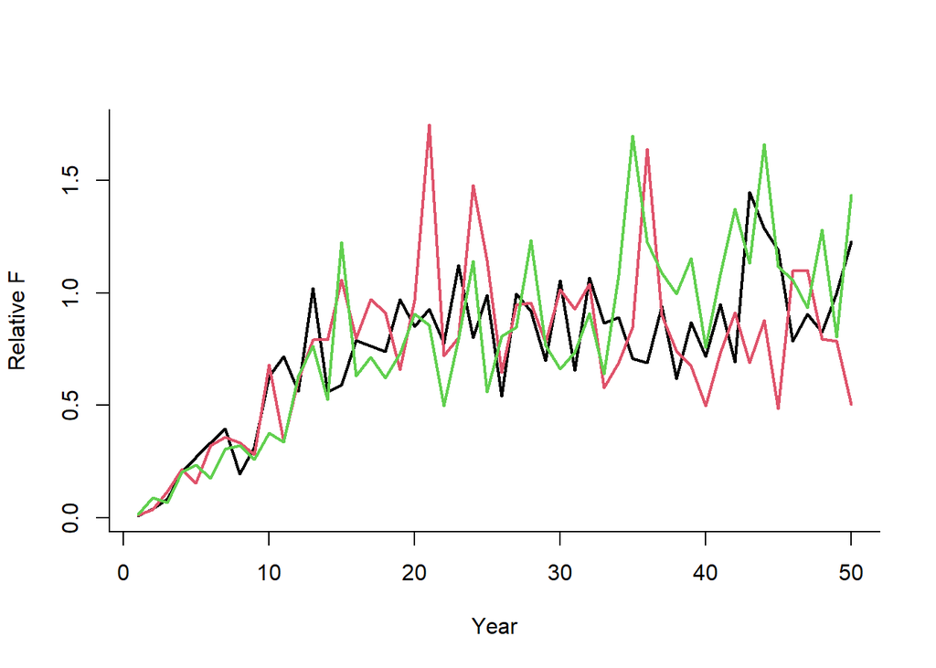

### Annual increase in catchability, interannual variability in catchability: qinc, qcv

**qinc**: Average percentage change in fishing efficiency (applicable only to forward projection and input controls). Uniform distribution lower and upper bounds. Non-negative real numbers

Specified Value(s): -2, 2

Borrowed from: Generic_Flat effort

**qcv**: Inter-annual variability in fishing efficiency (applicable only to forward projection and input controls). Uniform distribution lower and upper bounds. Non-negative real numbers

Specified Value(s): 0.1, 0.3

Borrowed from: Generic_Flat effort

### Future Catchability

#### Sampled Parameters

Histograms of 48 simulations of inter-annual variability in fishing efficiency (`qcv`) and average annual change in fishing efficiency (`qinc`), with vertical colored lines indicating 3 randomly drawn values used in the time-series plot:

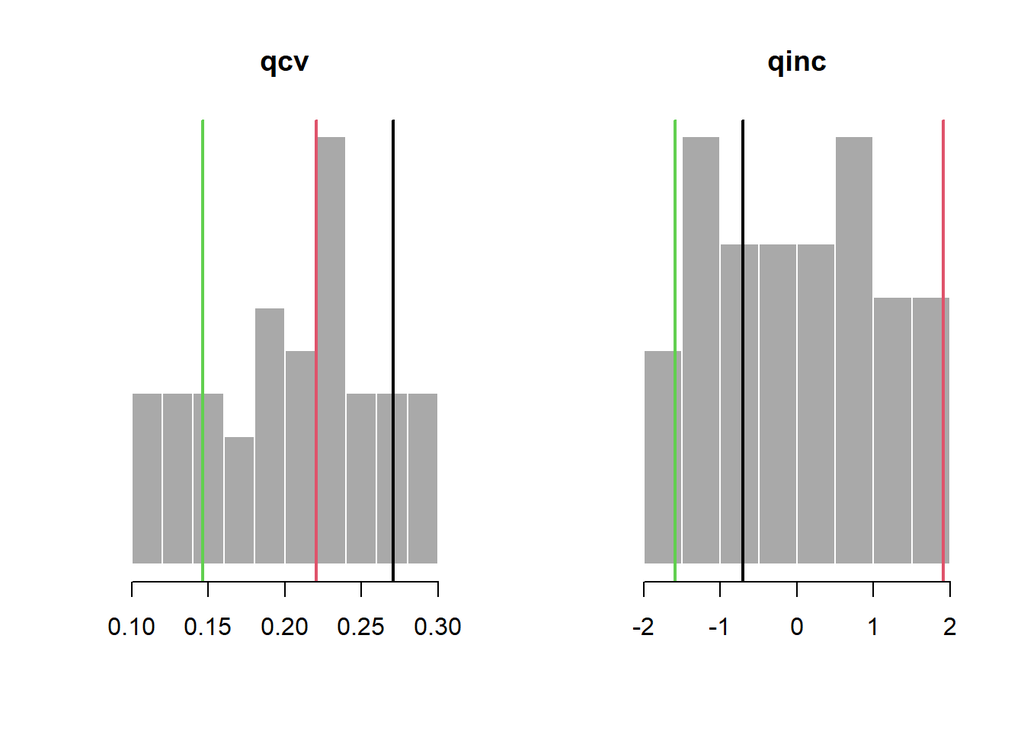

#### Time-Series

Time-series plot showing 3 trends in future fishing efficiency (catchability):

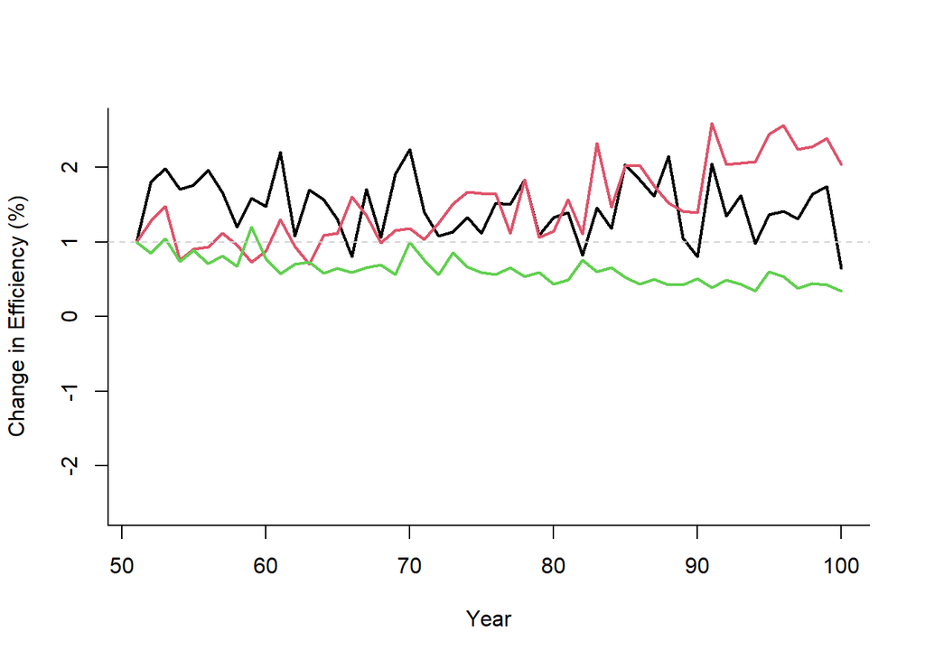

### Fishery gear length selectivity: L5, LFS, Vmaxlen, isRel

**L5**: Shortest length corresponding to 5 percent vulnerability. Uniform distribution lower and upper bounds. Positive real numbers

Specified Value(s): 0.2, 0.4

Borrowed from: Generic_Flat effort

**LFS**: Shortest length that is fully vulnerable to fishing. Uniform distribution lower and upper bounds. Positive real numbers

Specified Value(s): 0.75, 1.1

Borrowed from: Generic_Flat effort

**Vmaxlen**: The vulnerability of fish at Stock@Linf . Uniform distribution lower and upper bounds. Fraction

Specified Value(s): 0, 1

Borrowed from: Generic_Flat effort

**isRel**: Selectivity parameters in units of size-of-maturity (or absolute eg cm). Single value. Boolean

Specified Value(s): TRUE

Borrowed from: Generic_Flat effort

### Fishery length retention: LR5, LFR, Rmaxlen, DR

**LR5**: Shortest length corresponding at 5 percent retention. Uniform distribution lower and upper bounds. Non-negative real numbers

Specified Value(s): 0, 0

Borrowed from: Generic_Flat effort

**LFR**: Shortest length that is fully retained. Uniform distribution lower and upper bounds. Non-negative real numbers

Specified Value(s): 0, 0

Borrowed from: Generic_Flat effort

**Rmaxlen**: The retention of fish at Stock@Linf . Uniform distribution lower and upper bounds. Non-negative real numbers

Specified Value(s): 1, 1

Borrowed from: Generic_Flat effort

**DR**: Discard rate - the fraction of caught fish that are discarded. Uniform distribution lower and upper bounds. Fraction

Specified Value(s): 0, 0

Borrowed from: Generic_Flat effort

### Current Year: CurrentYr

**CurrentYr**: The current calendar year (final year) of the historical simulations (eg 2011). Single value. Positive integer

Specified Value(s): 50

Borrowed from: Generic_Flat effort

### Existing Spatial Closures: MPA

**MPA**: Is Area 1 currently closed (TRUE) or open (FALSE)? Defaults to FALSE

Specified Value(s): FALSE

Borrowed from: Generic_Flat effort

# Obs Parameters

### Catch statistics: Cobs, Cbiascv, CAA_nsamp, CAA_ESS, CAL_nsamp, CAL_ESS

**Cobs**: Log-normal catch observation error expressed as a coefficient of variation. Uniform distribution lower and upper bounds. Non-negative real numbers

Specified Value(s): 0.2, 0.6

Borrowed from: Imprecise-Unbiased

**Cbiascv**: Log-normal coefficient of variation controlling the sampling of bias in catch observations for each simulation. Single value. Non-negative real number

Specified Value(s): 0.05

Borrowed from: Imprecise-Unbiased

**CAA_nsamp**: Number of catch-at-age observation per time step. Uniform distribution lower and upper bounds. Positive real numbers

Specified Value(s): 50, 100

Borrowed from: Imprecise-Unbiased

**CAA_ESS**: Effective sample size (independent age draws) of the multinomial catch-at-age observation error model. Uniform distribution lower and upper bounds. Positive integers

Specified Value(s): 10, 20

Borrowed from: Imprecise-Unbiased

**CAL_nsamp**: Number of catch-at-length observation per time step. Uniform distribution lower and upper bounds. Positive integers

Specified Value(s): 50, 100

Borrowed from: Imprecise-Unbiased

**CAL_ESS**: Effective sample size (independent length draws) of the multinomial catch-at-length observation error model. Uniform distribution lower and upper bounds. Positive integers

Specified Value(s): 10, 20

Borrowed from: Imprecise-Unbiased

### Index imprecision, bias and hyperstability: Iobs, Btobs, Btbiascv, beta

**Iobs**: Observation error in the relative abundance indices expressed as a coefficient of variation. Uniform distribution lower and upper bounds. Positive real numbers

Specified Value(s): 0.2, 0.6

Borrowed from: Imprecise-Unbiased

**Btobs**: Log-normal coefficient of variation controlling error in observations of current stock biomass among years. Uniform distribution lower and upper bounds. Positive real numbers

Specified Value(s): 0.2, 0.5

Borrowed from: Imprecise-Unbiased

**Btbiascv**: Uniform-log bounds for sampling persistent bias in current stock biomass. Uniform-log distribution lower and upper bounds. Positive real numbers

Specified Value(s): 0.33, 3

Borrowed from: Imprecise-Unbiased

**beta**: A parameter controlling hyperstability/hyperdepletion where values below 1 lead to hyperstability (an index that decreases slower than true abundance) and values above 1 lead to hyperdepletion (an index that decreases more rapidly than true abundance). Uniform distribution lower and upper bounds. Positive real numbers

Specified Value(s): 0.67, 1.5

Borrowed from: Imprecise-Unbiased

### Bias in maturity, natural mortality rate and growth parameters: LenMbiascv, Mbiascv, Kbiascv,t0biascv, Linfbiascv

**LenMbiascv**: Log-normal coefficient of variation for sampling persistent bias in length at 50 percent maturity. Single value. Positive real numbers

Specified Value(s): 0.05

Borrowed from: Imprecise-Unbiased

**Mbiascv**: Log-normal coefficient of variation for sampling persistent bias in observed natural mortality rate. Single value. Positive real number

Specified Value(s): 0.05

Borrowed from: Imprecise-Unbiased

**Kbiascv**: Log-normal coefficient of variation for sampling persistent bias in observed growth parameter K. Single value. Positive real number

Specified Value(s): 0.05

Borrowed from: Imprecise-Unbiased

**t0biascv**: Log-normal coefficient of variation for sampling persistent bias in observed t0. Single value. Positive real number

Specified Value(s): 0.05

Borrowed from: Imprecise-Unbiased

**Linfbiascv**: Log-normal coefficient of variation for sampling persistent bias in observed maximum length. Single value. Positive real number

Specified Value(s): 0.05

Borrowed from: Imprecise-Unbiased

### Bias in length at first capture, length at full selection: LFCbiascv, LFSbiascv

**LFCbiascv**: Log-normal coefficient of variation for sampling persistent bias in observed length at first capture. Single value. Positive real number

Specified Value(s): 0.05

Borrowed from: Imprecise-Unbiased

**LFSbiascv**: Log-normal coefficient of variation for sampling persistent bias in length-at-full selection. Single value. Positive real number

Specified Value(s): 0.05

Borrowed from: Imprecise-Unbiased

### Bias in fishery reference points, unfished biomass, FMSY, FMSY/M ratio, biomass at MSY relative to unfished: FMSY_Mbiascv, BMSY_B0biascv

**FMSY_Mbiascv**: Log-normal coefficient of variation for sampling persistent bias in FMSY/M. Single value. Positive real number

Specified Value(s): 0.25

Borrowed from: Imprecise-Unbiased

**BMSY_B0biascv**: Log-normal coefficient of variation for sampling persistent bias in BMSY relative to unfished. Single value. Positive real number

Specified Value(s): 0.1

Borrowed from: Imprecise-Unbiased

### Management targets in terms of the index (i.e., model free), the total annual catches and absolute biomass levels: Irefbiascv, Crefbiascv, Brefbiascv

**Irefbiascv**: Log-normal coefficient of variation for sampling persistent bias in relative abundance index at BMSY. Single value. Positive real number

Specified Value(s): 0.1

Borrowed from: Imprecise-Unbiased

**Crefbiascv**: Log-normal coefficient of variation for sampling persistent bias in MSY. Single value. Positive real number

Specified Value(s): 0.1

Borrowed from: Imprecise-Unbiased

**Brefbiascv**: Log-normal coefficient of variation for sampling persistent bias in BMSY. Single value. Positive real number

Specified Value(s): 0.1

Borrowed from: Imprecise-Unbiased

### Depletion bias and imprecision: Dbiascv, Dobs

**Dbiascv**: Log-normal coefficient of variation for sampling persistent bias in stock depletion. Single value. Positive real number

Specified Value(s): 0.2

Borrowed from: Imprecise-Unbiased

**Dobs**: Log-normal coefficient of variation controlling error in observations of stock depletion among years. Uniform distribution lower and upper bounds. Positive real numbers

Specified Value(s): 0.05, 0.2

Borrowed from: Imprecise-Unbiased

### Recruitment compensation and trend: hbiascv, Recbiascv, sigmaRbiascv

**hbiascv**: Log-normal coefficient of variation for sampling persistent bias in steepness. Single value. Positive real number

Specified Value(s): 0.1

Borrowed from: Imprecise-Unbiased

**Recbiascv**: Log-normal coefficient of variation for sampling persistent bias in recent recruitment strength. Uniform distribution lower and upper bounds. Positive real numbers

Specified Value(s): 0.1, 0.3

Borrowed from: Imprecise-Unbiased

**sigmaRbiascv**: Log-normal coefficient of variation for sampling persistent bias in recruitment variability. Single value. Positive real number

Specified Value(s): 0.1

Borrowed from: Imprecise-Unbiased

### Effort: Eobs, Ebiascv

**Eobs**: Log-normal effort observation error expressed as a coefficient of variation. Uniform distribution lower and upper bounds. Non-negative real numbers

Specified Value(s): 0.2, 0.6

Borrowed from: Imprecise-Unbiased

**Ebiascv**: Log-normal coefficient of variation controlling the sampling of bias in effort observations for each simulation. Single value. Non-negative real number

Specified Value(s): 0.05

Borrowed from: Imprecise-Unbiased

## Observation Parameters

### Catch Observations

#### Sampled Parameters

Histograms of 48 simulations of inter-annual variability in catch observations (`Csd`) and persistent bias in observed catch (`Cbias`), with vertical colored lines indicating 3 randomly drawn values used in other plots:

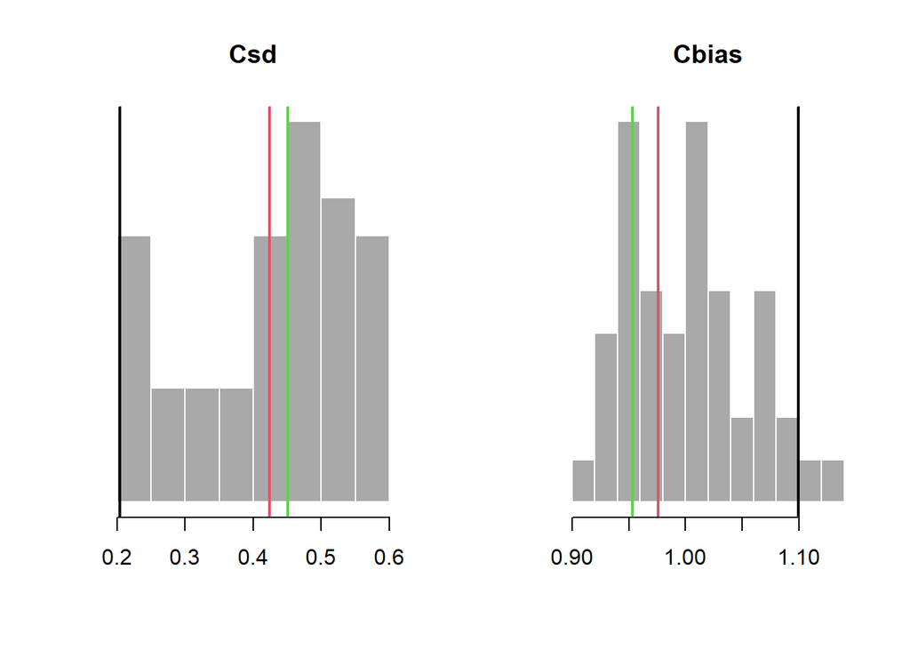

#### Time-Series

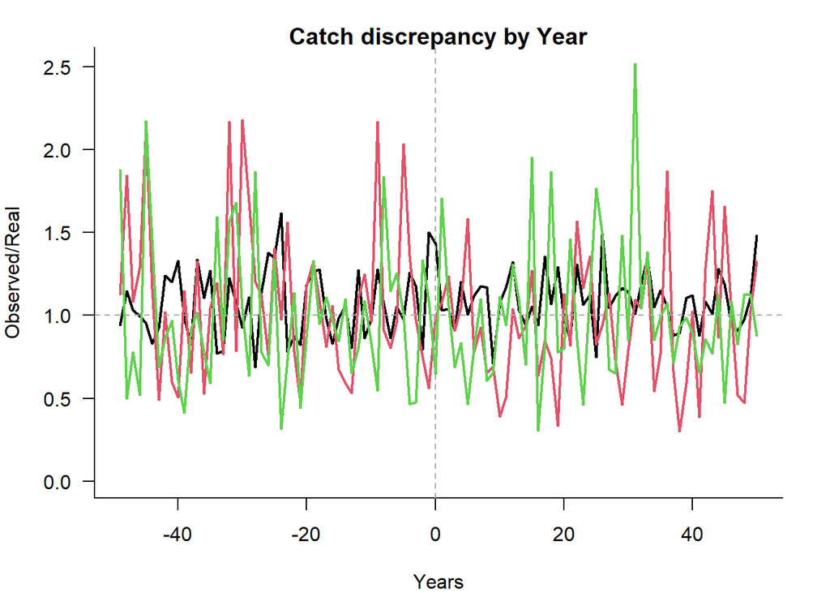

### Depletion Observations

#### Sampled Parameters

Histograms of 48 simulations of inter-annual variability in depletion observations (`Dobs`) and persistent bias in observed depletion (`Dbias`), with vertical colored lines indicating 3 randomly drawn values used in other plots:

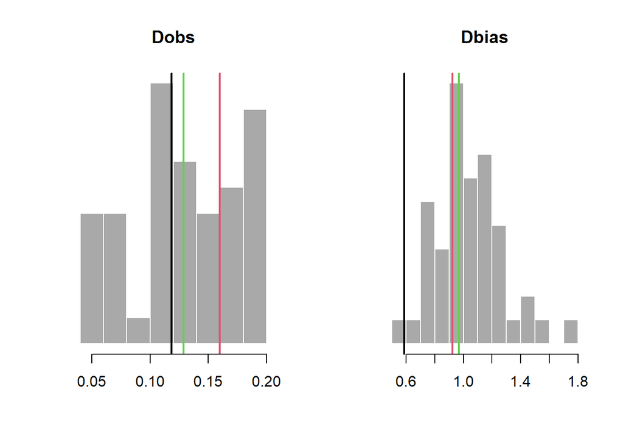

#### Time-Series

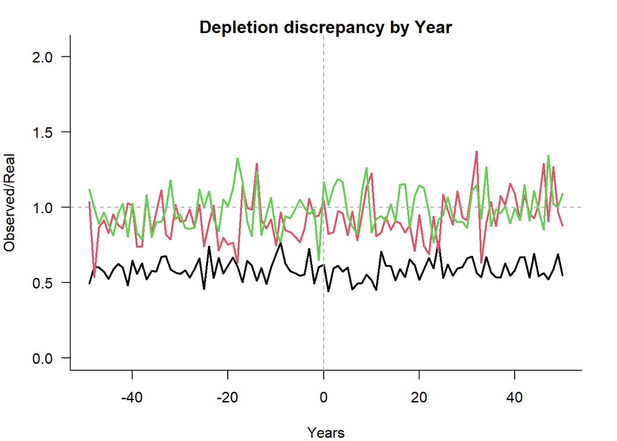

### Abundance Observations

#### Sampled Parameters

Histograms of 48 simulations of inter-annual variability in abundance observations (`Btobs`) and persistent bias in observed abundance (`Btbias`), with vertical colored lines indicating 3 randomly drawn values used in other plots:

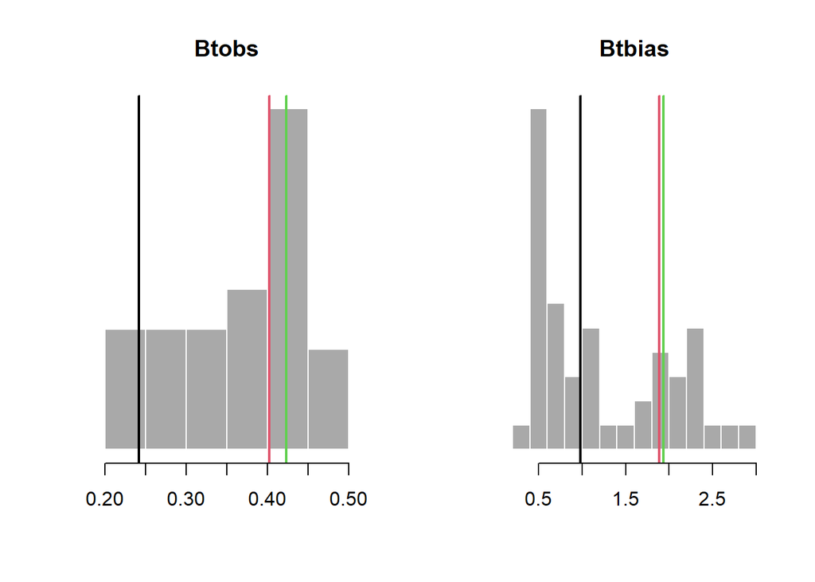

#### Time-Series

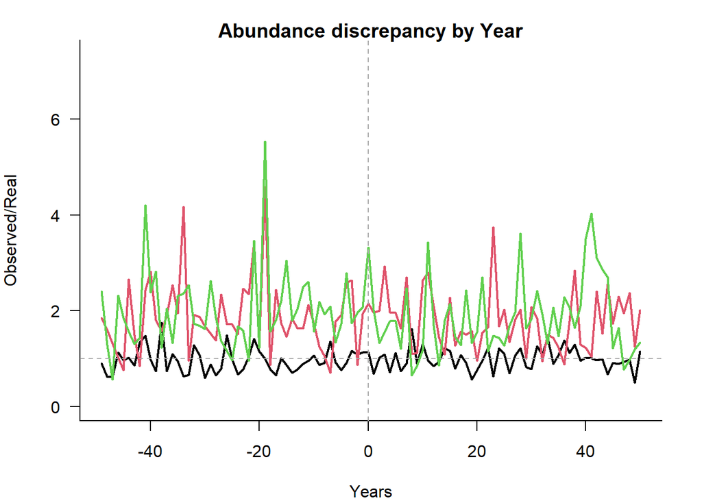